# Özge Bakay: Missing Verb Illusion

RePsychLing SMLP2022

Author

Reinhold Kliegl

Published

August 31, 2022

# 1 Background

The experiment investigates whether there is missing-verb illusion in Turkish center-embeddings and whether case similarity has an effect on the presence of illusion. The experiment has a 2x2 design where the factors are Grammaticality (Grammatical vs. Ungrammatical) and Case Similarity (High vs. Low). Both factors varied within-subject and within-item. The primary dependent variable is a 5-point rating.

With 56 (or 57) subjects and 24 items, assignment of items to conditions could not be counterbalanced across subjects. The assignment was not random because each item was seen by 20, 13, 13, and 11 subjects across the four conditions.

The gaol of the analysis is to test effects with a cumulative link mixed model for ordinal rating data, basically an integrated set of logistic regressions, taking into account clustering of ratings by subjects and by items.

# 2 Setup

```r
knitr::opts_chunk$set
```

```
function (...)
{
    set2(resolve(...))
}
<bytecode: 0x5645f5866e70>
<environment: 0x5645f587ea10>
```

```r
library(arrow)
library(readxl)
library(tidyverse)
library(easystats)
library(ordinal)
#library(summarytools)
library(sciplot)

# respecting color vision deficiency
cbPalette <- c( "#0072B2", "#D55E00", "#009E73", "#CC79A7",
                "#F0E442", "#56B4E9", "#999999", "#E69F00")
```

# 3 Preprocessing

- Extract a minimal data set
- My variable naming conventions
- For filtering decisions see original script

```r
df <-
  read_excel("./data/Bakay_Exp3 R Data.xlsx") |>
#  filter(Subject != 10) |>
  filter(Type == "exp") |>
  select(Subj = Subject, Item, trial=Trial, Case, Gram=Grammaticality,
         rating=RatingRATING, acc=AccuracyCOMP ) |>
  mutate(
    Subj = factor(paste0("S", str_pad(Subj, width = 2, side = "left", pad = "0"))),
    Item = factor(paste0("I", str_pad(Item, width = 2, side = "left", pad = "0"))),
    Gram = factor(Gram),
    Case = factor(Case)
    ) |>
  select(Subj, Item, trial, Case, Gram, rating)

#stview(dfSummary(df))
write_feather(df, "./data/Bakay_rating.arrow")
```

# 4 Figures

## 4.1 Case x Gram

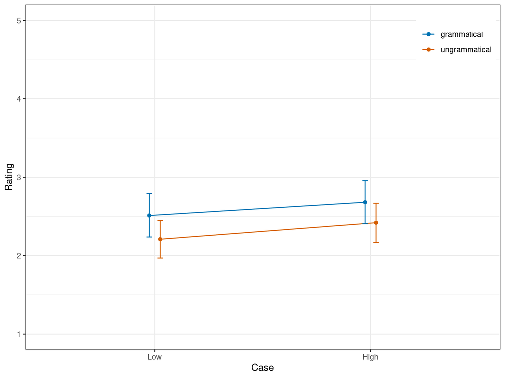

*Figure 1*. Case x Grammaticality interaction

```r
table1 <-
  df |>
  group_by(Subj, Case, Gram) |>
  summarise(N=n(), rating=mean(rating)) |>
  ungroup() |>
  group_by(Case, Gram) |>
  summarise(N=n(), rating_M=mean(rating),
            rating_SD=sd(rating), rating_SE=rating_SD/sqrt(N))
table1 |>
  mutate(Case=fct_rev(Case)) |>
  ggplot(aes(x=Case, y=rating_M, group=Gram, color=Gram)) +
  geom_point(position=position_dodge(width=.1)) +
  geom_line(position=position_dodge(width=.1)) +
  geom_errorbar(aes(ymax=rating_M + 2*rating_SE,
                    ymin=rating_M - 2*rating_SE), width=.05,
                position=position_dodge(width=.1)) +
  scale_color_manual("", labels=c("grammatical", "ungrammatical"), values=cbPalette)+
  scale_y_continuous("Rating", limits=c(1,5)) +
  theme_bw() + theme(legend.position = c(.99, .99), legend.justification = c(.99,.99))
```

## 4.2 Trial

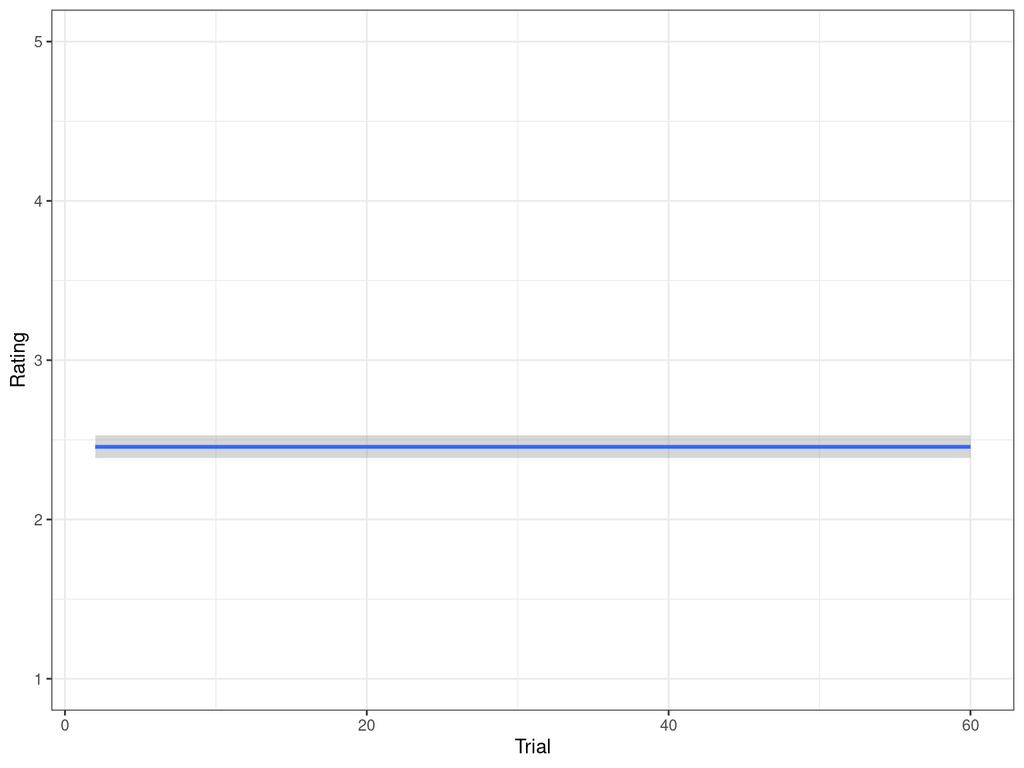

*Figure 2*. Trial main effect with default smooth() parameters.

```r
#|
df |>
  ggplot(aes(x=trial, y=rating)) +
  geom_smooth() +
  xlab("Trial") +
  scale_y_continuous("Rating", limits=c(1,5)) +
  theme_bw() + theme(legend.position = "top")
```

## 4.3 Trial x Case x Gram

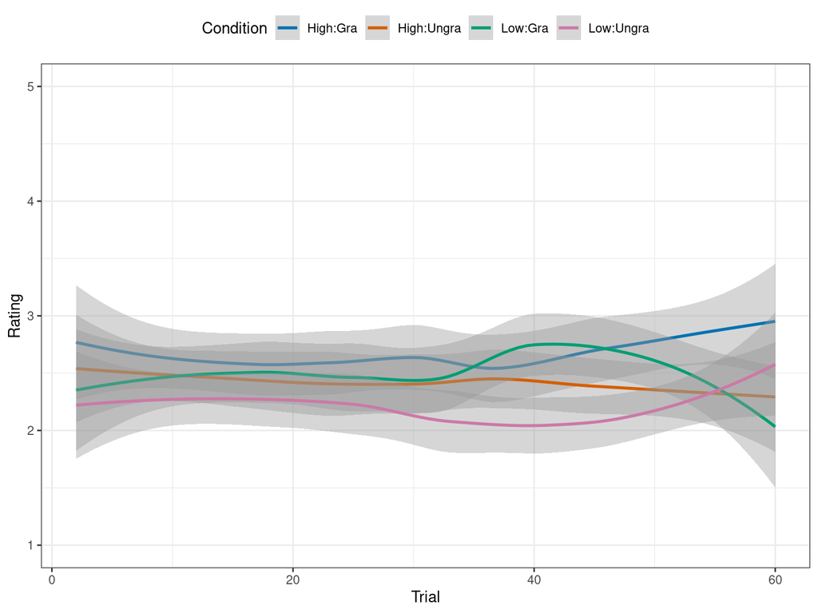

*Figure 3*. Trial effect for four conditions with default smooth() parameters.

```r
df |>
  ggplot(aes(x=trial, y=rating, group=Case:Gram, color=Case:Gram)) +
  geom_smooth() +
  xlab("Trial") +
  scale_y_continuous("Rating", limits=c(1,5)) +
  scale_colour_manual("Condition", values=cbPalette) +
  theme_bw() + theme(legend.position = "top")
```

Not much evidence for a trial effect.

# 5 CLMM

## 5.1 Varying only GM

```r
contrasts(df$Case) <- contr.sum(2)
contrasts(df$Gram) <- contr.sum(2)
df$tr_c <- df$trial-30

m0 <- clmm(as.factor(rating) ~ 1 + tr_c + Case * Gram + (1|Subj) + (1|Item), data=df)
summary(m0) # sig main effects of Case and Gram
```

```
Cumulative Link Mixed Model fitted with the Laplace approximation

formula: as.factor(rating) ~ 1 + tr_c + Case * Gram + (1 | Subj) + (1 |
    Item)
data:    df

 link  threshold nobs logLik   AIC     niter       max.grad cond.H
 logit flexible  1368 -1780.09 3580.18 1886(12803) 1.69e+01 2.2e+04

Random effects:
 Groups Name        Variance Std.Dev.
 Subj   (Intercept) 2.45233  1.566
 Item   (Intercept) 0.05714  0.239
Number of groups:  Subj 57,  Item 24

Coefficients:
              Estimate Std. Error z value Pr(>|z|)
tr_c        -0.0008326  0.0029980  -0.278   0.7812
Case1        0.1612975  0.0513876   3.139   0.0017 **
Gram1        0.2344701  0.0518116   4.525 6.03e-06 ***
Case1:Gram1 -0.0225782  0.0511494  -0.441   0.6589
---
Signif. codes:  0 '***' 0.001 '**' 0.01 '*' 0.05 '.' 0.1 ' ' 1

Threshold coefficients:
    Estimate Std. Error z value
1|2  -1.2476     0.2254  -5.536
2|3   0.2444     0.2236   1.093
3|4   1.5289     0.2279   6.709
4|5   2.9121     0.2432  11.972
```

```r
m1 <- clmm(as.factor(rating) ~ 1 + Case * Gram + (1|Subj) + (1|Item), data=df)
summary(m1) # sig main effects of Case and Gram
```

```
Cumulative Link Mixed Model fitted with the Laplace approximation

formula: as.factor(rating) ~ 1 + Case * Gram + (1 | Subj) + (1 | Item)
data:    df

 link  threshold nobs logLik   AIC     niter       max.grad cond.H
 logit flexible  1368 -1777.67 3573.34 1739(12592) 9.85e-04 1.3e+02

Random effects:
 Groups Name        Variance Std.Dev.
 Subj   (Intercept) 3.41200  1.8472
 Item   (Intercept) 0.06545  0.2558
Number of groups:  Subj 57,  Item 24

Coefficients:
            Estimate Std. Error z value Pr(>|z|)
Case1        0.17797    0.05203   3.421 0.000625 ***
Gram1        0.24918    0.05255   4.742 2.12e-06 ***
Case1:Gram1 -0.02662    0.05180  -0.514 0.607288
---
Signif. codes:  0 '***' 0.001 '**' 0.01 '*' 0.05 '.' 0.1 ' ' 1

Threshold coefficients:
    Estimate Std. Error z value
1|2  -1.3069     0.2612  -5.003
2|3   0.2461     0.2597   0.948
3|4   1.6049     0.2640   6.079
4|5   3.1218     0.2804  11.135
```

```r
anova(m1, m0)
```

```
Likelihood ratio tests of cumulative link models:

   formula:                                                             link:
m1 as.factor(rating) ~ 1 + Case * Gram + (1 | Subj) + (1 | Item)        logit
m0 as.factor(rating) ~ 1 + tr_c + Case * Gram + (1 | Subj) + (1 | Item) logit
   threshold:
m1 flexible
m0 flexible

   no.par    AIC  logLik LR.stat df Pr(>Chisq)
m1      9 3573.3 -1777.7
m0     10 3580.2 -1780.1 -4.8404  1          1
```

We don’t need trial as a covariate. Probably, we could also drop the interaction at least from the random-effect structure.

## 5.2 Individual and item differences in main effects

Relative to the factorial design this is not the maximal CLMM; we do not include Subj- and Item-related VCs for the interaction term.

```r
f2 <- "./fits/Bakay_m2_clmm.rda"
if(!file.exists(f2)){
  m2 <- clmm(as.factor(rating) ~ 1 + Case * Gram + (1 + Case + Gram | Subj) + (1 + Case + Gram | Item),
             data=df)
  save(m2, file=f2)
} else load(f2)

summary(m2)
```

```
Cumulative Link Mixed Model fitted with the Laplace approximation

formula: as.factor(rating) ~ 1 + Case * Gram + (1 + Case + Gram | Subj) +
    (1 + Case + Gram | Item)
data:    df

 link  threshold nobs logLik   AIC     niter       max.grad cond.H
 logit flexible  1368 -1749.10 3536.19 2664(16183) 1.79e-03 1.2e+06

Random effects:
 Groups Name        Variance  Std.Dev. Corr
 Subj   (Intercept) 5.0454534 2.24621
        CaseLow     0.0002955 0.01719  -1.000
        GramUngra   1.7063847 1.30629  -0.521  0.521
 Item   (Intercept) 0.2032667 0.45085
        CaseLow     0.1067584 0.32674  -0.547
        GramUngra   0.0808627 0.28436  -0.985  0.683
Number of groups:  Subj 57,  Item 24

Coefficients:
            Estimate Std. Error z value Pr(>|z|)
Case1        0.18780    0.06265   2.998  0.00272 **
Gram1        0.31284    0.10772   2.904  0.00368 **
Case1:Gram1 -0.03348    0.05292  -0.633  0.52694
---
Signif. codes:  0 '***' 0.001 '**' 0.01 '*' 0.05 '.' 0.1 ' ' 1

Threshold coefficients:
    Estimate Std. Error z value
1|2  -1.4037     0.2793  -5.025
2|3   0.2468     0.2778   0.888
3|4   1.7097     0.2827   6.048
4|5   3.3840     0.3024  11.189
```

```r
anova(m1, m2)
```

```
Likelihood ratio tests of cumulative link models:

   formula:
m1 as.factor(rating) ~ 1 + Case * Gram + (1 | Subj) + (1 | Item)
m2 as.factor(rating) ~ 1 + Case * Gram + (1 + Case + Gram | Subj) + (1 + Case + Gram | Item)
   link: threshold:
m1 logit flexible
m2 logit flexible

   no.par    AIC  logLik LR.stat df Pr(>Chisq)
m1      9 3573.3 -1777.7
m2     19 3536.2 -1749.1  57.145 10  1.252e-08 ***
---
Signif. codes:  0 '***' 0.001 '**' 0.01 '*' 0.05 '.' 0.1 ' ' 1
```

The main effects stay significant. The random-effect structure looks overparaemterized because some of the CP are or are very close to -1.00, that is at the boundary.

## 5.3 Zero-correlation parameters CLMM

```r
mm <- model.matrix(~ 1 + Case*Gram, data=df)
case <- mm[,2]
gram <- mm[,3]

m3 <- clmm(as.factor(rating) ~ 1 + case * gram + (1  | Subj) + (0 + case | Subj) + (0 + gram | Subj) +
                                                 (1  | Item) + (0 + case | Item) + (0 + gram | Item), data=df)
summary(m3)
```

```
Cumulative Link Mixed Model fitted with the Laplace approximation

formula: as.factor(rating) ~ 1 + case * gram + (1 | Subj) + (0 + case |
    Subj) + (0 + gram | Subj) + (1 | Item) + (0 + case | Item) +
    (0 + gram | Item)
data:    df

 link  threshold nobs logLik   AIC     niter       max.grad cond.H
 logit flexible  1368 -1752.05 3530.11 2186(13561) 1.25e-03 1.3e+02

Random effects:
 Groups Name        Variance Std.Dev.
 Subj   gram        0.414184 0.64357
 Subj   case        0.000000 0.00000
 Subj   (Intercept) 3.812065 1.95245
 Item   gram        0.001548 0.03934
 Item   case        0.019841 0.14086
 Item   (Intercept) 0.070741 0.26597
Number of groups:  Subj 57,  Item 24

Coefficients:
          Estimate Std. Error z value Pr(>|z|)
case       0.18705    0.06018   3.108  0.00188 **
gram       0.30526    0.10264   2.974  0.00294 **
case:gram -0.03544    0.05277  -0.672  0.50181
---
Signif. codes:  0 '***' 0.001 '**' 0.01 '*' 0.05 '.' 0.1 ' ' 1

Threshold coefficients:
    Estimate Std. Error z value
1|2  -1.3903     0.2758  -5.040
2|3   0.2559     0.2741   0.934
3|4   1.7098     0.2791   6.127
4|5   3.3678     0.2990  11.264
```

```r
anova(m1, m3, m2)
```

```
Likelihood ratio tests of cumulative link models:

   formula:
m1 as.factor(rating) ~ 1 + Case * Gram + (1 | Subj) + (1 | Item)
m3 as.factor(rating) ~ 1 + case * gram + (1 | Subj) + (0 + case | Subj) + (0 + gram | Subj) + (1 | Item) + (0 + case | Item) + (0 + gram | Item)
m2 as.factor(rating) ~ 1 + Case * Gram + (1 + Case + Gram | Subj) + (1 + Case + Gram | Item)
   link: threshold:
m1 logit flexible
m3 logit flexible
m2 logit flexible

   no.par    AIC  logLik LR.stat df Pr(>Chisq)
m1      9 3573.3 -1777.7
m3     13 3530.1 -1752.1 51.2271  4  2.001e-10 ***
m2     19 3536.2 -1749.1  5.9174  6     0.4325
---
Signif. codes:  0 '***' 0.001 '**' 0.01 '*' 0.05 '.' 0.1 ' ' 1
```

Some of the VCs are very close to zero.

## 5.4 Parsimonious CLMM

```r
m4 <- clmm(as.factor(rating) ~ 1 + case * gram + (1  | Subj) + (0 + gram | Subj) +
                                                 (1  | Item) + (0 + case | Item) , data=df)
summary(m4)
```

```
Cumulative Link Mixed Model fitted with the Laplace approximation

formula: as.factor(rating) ~ 1 + case * gram + (1 | Subj) + (0 + gram |
    Subj) + (1 | Item) + (0 + case | Item)
data:    df

 link  threshold nobs logLik   AIC     niter      max.grad cond.H
 logit flexible  1368 -1752.06 3526.12 1121(6971) 8.19e-04 1.3e+02

Random effects:
 Groups Name        Variance Std.Dev.
 Subj   gram        0.41390  0.6433
 Subj   (Intercept) 3.81053  1.9521
 Item   case        0.01985  0.1409
 Item   (Intercept) 0.07074  0.2660
Number of groups:  Subj 57,  Item 24

Coefficients:
          Estimate Std. Error z value Pr(>|z|)
case       0.18687    0.06013   3.108  0.00189 **
gram       0.30520    0.10229   2.984  0.00285 **
case:gram -0.03539    0.05276  -0.671  0.50237
---
Signif. codes:  0 '***' 0.001 '**' 0.01 '*' 0.05 '.' 0.1 ' ' 1

Threshold coefficients:
    Estimate Std. Error z value
1|2  -1.3898     0.2757  -5.041
2|3   0.2561     0.2740   0.934
3|4   1.7094     0.2790   6.128
4|5   3.3669     0.2987  11.271
```

```r
anova(m1, m4, m3, m2)
```

```
Likelihood ratio tests of cumulative link models:

   formula:
m1 as.factor(rating) ~ 1 + Case * Gram + (1 | Subj) + (1 | Item)
m4 as.factor(rating) ~ 1 + case * gram + (1 | Subj) + (0 + gram | Subj) + (1 | Item) + (0 + case | Item)
m3 as.factor(rating) ~ 1 + case * gram + (1 | Subj) + (0 + case | Subj) + (0 + gram | Subj) + (1 | Item) + (0 + case | Item) + (0 + gram | Item)
m2 as.factor(rating) ~ 1 + Case * Gram + (1 + Case + Gram | Subj) + (1 + Case + Gram | Item)
   link: threshold:
m1 logit flexible
m4 logit flexible
m3 logit flexible
m2 logit flexible

   no.par    AIC  logLik LR.stat df Pr(>Chisq)
m1      9 3573.3 -1777.7
m4     11 3526.1 -1752.1 51.2215  2  7.541e-12 ***
m3     13 3530.1 -1752.1  0.0057  2     0.9972
m2     19 3536.2 -1749.1  5.9174  6     0.4325
---
Signif. codes:  0 '***' 0.001 '**' 0.01 '*' 0.05 '.' 0.1 ' ' 1
```

Looking good!

## 5.5 Extending the parsimonious CLMM with CPs

```r
m5 <- clmm(as.factor(rating) ~ 1 + Case * Gram + (1 + Gram | Subj) +  (1 + Case| Item) , data=df)
summary(m5)
```

```
Cumulative Link Mixed Model fitted with the Laplace approximation

formula: as.factor(rating) ~ 1 + Case * Gram + (1 + Gram | Subj) + (1 +
    Case | Item)
data:    df

 link  threshold nobs logLik   AIC     niter       max.grad cond.H
 logit flexible  1368 -1751.12 3528.24 1683(10234) 1.72e-03 1.3e+02

Random effects:
 Groups Name        Variance Std.Dev. Corr
 Subj   (Intercept) 4.91346  2.2166
        GramUngra   1.67131  1.2928   -0.517
 Item   (Intercept) 0.08058  0.2839
        CaseLow     0.07941  0.2818   -0.378
Number of groups:  Subj 57,  Item 24

Coefficients:
            Estimate Std. Error z value Pr(>|z|)
Case1        0.18691    0.06014   3.108  0.00188 **
Gram1        0.31058    0.10287   3.019  0.00253 **
Case1:Gram1 -0.03397    0.05276  -0.644  0.51969
---
Signif. codes:  0 '***' 0.001 '**' 0.01 '*' 0.05 '.' 0.1 ' ' 1

Threshold coefficients:
    Estimate Std. Error z value
1|2  -1.3964     0.2770  -5.042
2|3   0.2471     0.2754   0.897
3|4   1.7018     0.2803   6.072
4|5   3.3658     0.2999  11.222
```

```r
anova( m4, m5)
```

```
Likelihood ratio tests of cumulative link models:

   formula:
m4 as.factor(rating) ~ 1 + case * gram + (1 | Subj) + (0 + gram | Subj) + (1 | Item) + (0 + case | Item)
m5 as.factor(rating) ~ 1 + Case * Gram + (1 + Gram | Subj) + (1 + Case | Item)
   link: threshold:
m4 logit flexible
m5 logit flexible

   no.par    AIC  logLik LR.stat df Pr(>Chisq)
m4     11 3526.1 -1752.1
m5     13 3528.2 -1751.1   1.874  2     0.3918
```

Looking also good, but the two CPs are not significant.

# 6 Summary

- There is evidence for significant individual differences in the effect of Gram and in the Grand Mean
- There is evidence for significant item differences in the effect of Case and in the Grand Mean
- There is no evidence for correlation parameters.
- There are two significant main effects of Case and Gram, irrespective of the complexity of the random-effect struture.

# 7 Appendix